# e13

1.导入digits数据：

```python
from sklearn.datasets import load_digits
digits = load_digits()
#digits
```

```python
#digits.images
#digits.data
#digits.target
```

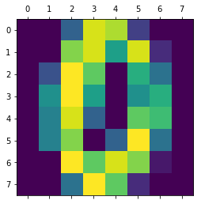

```python
import matplotlib.pyplot as plt
plt.matshow(digits.images[666])
plt.show()
```

2.标准化数据和PCA降维。（可选步骤）

```python
from sklearn.cluster import KMeans
from sklearn.cluster import AgglomerativeClustering
from sklearn.preprocessing import scale
from sklearn.preprocessing import StandardScaler
from sklearn.preprocessing import scale
from sklearn.decomposition import PCA
from sklearn.datasets import make_blobs
import numpy as np
import time
```

```python
#data = scale(digits.data)#数据正则化
data = digits.data
n_samples = data.shape
n_samples
data
```

```
array([[  0.,   0.,   5., ...,   0.,   0.,   0.],
       [  0.,   0.,   0., ...,  10.,   0.,   0.],
       [  0.,   0.,   0., ...,  16.,   9.,   0.],
       ...,
       [  0.,   0.,   1., ...,   6.,   0.,   0.],
       [  0.,   0.,   2., ...,  12.,   0.,   0.],
       [  0.,   0.,  10., ...,  12.,   1.,   0.]])
```

```python
labels = digits.target
labels
```

```
array([0, 1, 2, ..., 8, 9, 8])
```

```python
model = StandardScaler().fit(data)#标准差标准化
data_std = model.transform(data)
```

```python
data_std
```

```
array([[ 0.        , -0.33501649, -0.04308102, ..., -1.14664746,
        -0.5056698 , -0.19600752],
       [ 0.        , -0.33501649, -1.09493684, ...,  0.54856067,
        -0.5056698 , -0.19600752],
       [ 0.        , -0.33501649, -1.09493684, ...,  1.56568555,
         1.6951369 , -0.19600752],
       ...,
       [ 0.        , -0.33501649, -0.88456568, ..., -0.12952258,
        -0.5056698 , -0.19600752],
       [ 0.        , -0.33501649, -0.67419451, ...,  0.8876023 ,
        -0.5056698 , -0.19600752],
       [ 0.        , -0.33501649,  1.00877481, ...,  0.8876023 ,
        -0.26113572, -0.19600752]])
```

```python
pca_model = PCA(n_components=10).fit(data)
data_pca = pca_model.transform(data_std)
data_pca
```

```
array([[ -3.10277836e-01,   5.47905242e+00,  -4.44807598e+00, ...,
          1.10508307e+01,   7.93777345e+00,   3.54531945e+01],
       [  1.19235257e+00,  -1.81546359e+00,  -1.82085596e+00, ...,
          9.38567079e+00,   8.51111213e+00,   3.47074485e+01],
       [  1.23324870e+00,  -3.44266631e-02,  -2.01517158e+00, ...,
          7.36351317e+00,   8.00051371e+00,   3.59576895e+01],
       ...,
       [  1.57109520e+00,   4.57284538e-01,  -1.68039390e+00, ...,
          8.84078660e+00,   7.22366139e+00,   3.27135215e+01],
       [ -9.66026534e-01,   3.88299979e+00,  -4.34925746e+00, ...,
          9.58157636e+00,   8.78932192e+00,   3.25460472e+01],
       [ -5.43696549e-01,   2.85004181e+00,  -3.40502668e-01, ...,
          1.05840723e+01,   7.02538894e+00,   3.28397401e+01]])
```

3.聚类，并想办法获取每个类代表的是什么数字（标签）。

```python
X = data_pca
y = digits.target
n_digits = len(np.unique(digits.target))
#n_digits
```

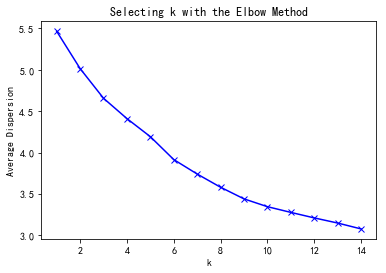

```python
from scipy.spatial.distance import cdist
K=range(1,15)
meandistortions=[]

for k in K:
    kmeans=KMeans(n_clusters=k)
    kmeans.fit(X)
    meandistortions.append(sum(np.min(cdist(X,kmeans.cluster_centers_,'euclidean'),axis=1))/X.shape[0])
plt.plot(K,meandistortions,'bx-')
plt.xlabel('k')
plt.ylabel('Average Dispersion')
plt.title('Selecting k with the Elbow Method')
plt.show()
#图中没有明显拐点的存在，因此采用另一种方法
```

```python
from sklearn import metrics
a = [1,2,3,4,5,6,7,8,9,10,11,12,13,14]

for i in a:
    y_test = KMeans(n_clusters=i, random_state=random_state).fit_predict(X)
    Y_test = AgglomerativeClustering(affinity='euclidean',linkage='ward',n_clusters=i).fit_predict(X)
    print('Kmeans',metrics.adjusted_rand_score(labels,y_test),'系统聚类',metrics.adjusted_rand_score(labels,Y_test))
    #print('系统聚类',metrics.adjusted_rand_score(digits.target,Y_test))
```

```
Kmeans 0.0 系统聚类 0.0
Kmeans 0.137723217456 系统聚类 0.136684271628
Kmeans 0.237620214183 系统聚类 0.26729828334
Kmeans 0.282571432705 系统聚类 0.335415034338
Kmeans 0.38148811138 系统聚类 0.365351943779
Kmeans 0.409333713843 系统聚类 0.424629883766
Kmeans 0.476009449033 系统聚类 0.546679195961
Kmeans 0.546065450979 系统聚类 0.660757280942
Kmeans 0.578940269166 系统聚类 0.690057196802
Kmeans 0.635161937891 系统聚类 0.742831223068
Kmeans 0.621379726139 系统聚类 0.752920688367
Kmeans 0.601069806227 系统聚类 0.724916063394
Kmeans 0.645231050871 系统聚类 0.709246164537
Kmeans 0.64528766984 系统聚类 0.680450688117
```

由上得出两种聚类方法的最佳n_clusters值

```python
plt.rcParams['font.sans-serif'] = 'SimHei' ## 设置中文显示
plt.rcParams['axes.unicode_minus'] = False
random_state = 170
```

[figure not shown]

```python
#Kmeans
k_start =time.clock()
plt.figure(figsize=(10,10))
# y_pre1 = KMeans(n_clusters=2, random_state=random_state).fit_predict(X)

# plt.subplot(221)
# plt.scatter(X[y_pre1==0][:, 0], X[y_pre1==0][:, 1], marker='x',color='b')
# plt.scatter(X[y_pre1==1][:, 0], X[y_pre1==1][:, 1], marker='+',color='r')
# plt.title("Incorrect Number of Blobs")

# 聚类数量正确时的效果
y_pre2 = KMeans(n_clusters=n_digits, random_state=random_state).fit_predict(X)

#plt.subplot(222)
plt.scatter(X[y_pre2==0][:, 0], X[y_pre2==0][:, 1], marker='x',color='b')
plt.scatter(X[y_pre2==1][:, 0], X[y_pre2==1][:, 1], marker='+',color='r')
plt.scatter(X[y_pre2==2][:, 0], X[y_pre2==2][:, 1], marker='1',color='g')
plt.scatter(X[y_pre2==3][:, 0], X[y_pre2==3][:, 1], marker='1',color='c')
plt.scatter(X[y_pre2==4][:, 0], X[y_pre2==4][:, 1], marker='1',color='m')
plt.scatter(X[y_pre2==5][:, 0], X[y_pre2==5][:, 1], marker='1',color='y')
plt.scatter(X[y_pre2==6][:, 0], X[y_pre2==6][:, 1], marker='1',color='k')
plt.scatter(X[y_pre2==7][:, 0], X[y_pre2==7][:, 1], marker='1',color='brown')
plt.scatter(X[y_pre2==8][:, 0], X[y_pre2==8][:, 1], marker='1',color='hotpink')
plt.scatter(X[y_pre2==9][:, 0], X[y_pre2==9][:, 1], marker='1',color='skyblue')

plt.title("Kmeans")

plt.show()
k_end = time.clock()
```

```python
print('kmeans运行时间: %s Seconds'%(k_end-k_start))
```

```
kmeans运行时间: 0.2846330852347876 Seconds
```

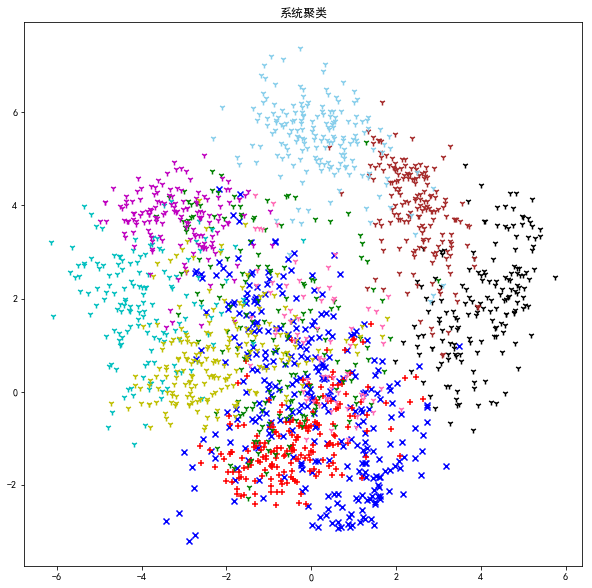

```python
#系统聚类
x_start =time.clock()
plt.figure(figsize=(10,10))
# # 聚类数量不正确时的效果
# y_pred1 = AgglomerativeClustering(affinity='euclidean',linkage='ward',n_clusters=2).fit_predict(X)
# # 选取欧几里德距离和离差平均和法
# plt.subplot(221)
# plt.scatter(X[y_pred1==0][:, 0], X[y_pred1==0][:, 1], marker='x',color='b')
# plt.scatter(X[y_pred1==1][:, 0], X[y_pred1==1][:, 1], marker='+',color='r')
# plt.title("Incorrect Number of Blobs")

# 聚类数量正确时的效果
y_pred2 = AgglomerativeClustering(affinity='euclidean',linkage='ward',n_clusters=n_digits).fit_predict(X)

# plt.subplot(222)
plt.scatter(X[y_pred2==0][:, 0], X[y_pred2==0][:, 1], marker='x',color='b')
plt.scatter(X[y_pred2==1][:, 0], X[y_pred2==1][:, 1], marker='+',color='r')
plt.scatter(X[y_pred2==2][:, 0], X[y_pred2==2][:, 1], marker='1',color='g')
plt.scatter(X[y_pred2==3][:, 0], X[y_pred2==3][:, 1], marker='1',color='c')
plt.scatter(X[y_pred2==4][:, 0], X[y_pred2==4][:, 1], marker='1',color='m')
plt.scatter(X[y_pred2==5][:, 0], X[y_pred2==5][:, 1], marker='1',color='y')
plt.scatter(X[y_pred2==6][:, 0], X[y_pred2==6][:, 1], marker='1',color='k')
plt.scatter(X[y_pred2==7][:, 0], X[y_pred2==7][:, 1], marker='1',color='brown')
plt.scatter(X[y_pred2==8][:, 0], X[y_pred2==8][:, 1], marker='1',color='hotpink')
plt.scatter(X[y_pred2==9][:, 0], X[y_pred2==9][:, 1], marker='1',color='skyblue')
plt.title("系统聚类")

plt.show()
x_end = time.clock()
```

```python
print('系统聚类运行时间: %s Seconds'%(x_end-x_start))
```

```
系统聚类运行时间: 0.41896148698668867 Seconds
```

```python
print(metrics.adjusted_rand_score(digits.target,y_pre2))
print(metrics.adjusted_rand_score(digits.target,y_pred2))
```

```
0.635161937891
0.742831223068
```

```python
# for i in labels:
#     print(i)
```

```python
# for i in y_pred2:
#     print(i)
```

```python
# for i in y_pre2:
#     print(i)
```

```python
import pandas as pd
new = [labels,y_pre2,y_pred2]
df = pd.DataFrame(new)
df
```

|  | 0 | 1 | 2 | 3 | 4 | 5 | 6 | 7 | 8 | 9 | ... | 1787 | 1788 | 1789 | 1790 | 1791 | 1792 | 1793 | 1794 | 1795 | 1796 |
| --- | --- | --- | --- | --- | --- | --- | --- | --- | --- | --- | --- | --- | --- | --- | --- | --- | --- | --- | --- | --- | --- |
| 0 | 0 | 1 | 2 | 3 | 4 | 5 | 6 | 7 | 8 | 9 | ... | 5 | 4 | 8 | 8 | 4 | 9 | 0 | 8 | 9 | 8 |
| 1 | 2 | 9 | 9 | 7 | 1 | 3 | 5 | 8 | 7 | 3 | ... | 3 | 1 | 9 | 9 | 1 | 3 | 2 | 9 | 3 | 3 |
| 2 | 9 | 0 | 0 | 3 | 6 | 4 | 7 | 1 | 0 | 4 | ... | 2 | 6 | 0 | 0 | 6 | 4 | 9 | 0 | 4 | 0 |

3 rows × 1797 columns

```python
def count(listname,num):
    count1 = listname.count(num)
    print('数字',num,"出现的次数是:",count1)
    #return count1
```

```python
def countnum(tn):
    name=[]
    for i in range(0,1797):
        if df.iat[0,i]==tn:
            name.append(df.iat[1,i])
    #count = zero1.count(1)
    count_list = []
    for j in range(0,11):
        #count_list.append(count(zero1,j))
        count(name,j)
    # for num in count_list:
    #     if num == np.max(count_list)
def countnum1(tn):
    name=[]
    for i in range(0,1797):
        if df.iat[0,i]==tn:
            name.append(df.iat[2,i])
    count_list = []
    for j in range(0,11):
        count(name,j)
```

```python
print('kmeans：\n')
for k in range(0,10):
    print('匹配数字',k,'的结果：')
    countnum(k)
```

```
kmeans：

匹配数字 0 的结果：
数字 0 出现的次数是: 0
数字 1 出现的次数是: 3
数字 2 出现的次数是: 173
数字 3 出现的次数是: 0
数字 4 出现的次数是: 0
数字 5 出现的次数是: 2
数字 6 出现的次数是: 0
数字 7 出现的次数是: 0
数字 8 出现的次数是: 0
数字 9 出现的次数是: 0
数字 10 出现的次数是: 0
匹配数字 1 的结果：
数字 0 出现的次数是: 25
数字 1 出现的次数是: 0
数字 2 出现的次数是: 0
数字 3 出现的次数是: 0
数字 4 出现的次数是: 56
数字 5 出现的次数是: 2
数字 6 出现的次数是: 1
数字 7 出现的次数是: 0
数字 8 出现的次数是: 0
数字 9 出现的次数是: 98
数字 10 出现的次数是: 0
匹配数字 2 的结果：
数字 0 出现的次数是: 154
数字 1 出现的次数是: 0
数字 2 出现的次数是: 1
数字 3 出现的次数是: 1
数字 4 出现的次数是: 4
数字 5 出现的次数是: 0
数字 6 出现的次数是: 0
数字 7 出现的次数是: 7
数字 8 出现的次数是: 2
数字 9 出现的次数是: 8
数字 10 出现的次数是: 0
匹配数字 3 的结果：
数字 0 出现的次数是: 2
```

[output cut: 67 more lines]

```
数字 8 出现的次数是: 3
数字 9 出现的次数是: 80
数字 10 出现的次数是: 0
匹配数字 9 的结果：
数字 0 出现的次数是: 0
数字 1 出现的次数是: 0
数字 2 出现的次数是: 0
数字 3 出现的次数是: 140
数字 4 出现的次数是: 20
数字 5 出现的次数是: 0
数字 6 出现的次数是: 7
数字 7 出现的次数是: 5
数字 8 出现的次数是: 8
数字 9 出现的次数是: 0
数字 10 出现的次数是: 0
```

由上可得知实际列表的数字在kmeans中：0匹配2,1匹配9,2匹配0,3匹配7,4匹配1,5匹配6,6匹配5,7匹配8,8匹配9，9匹配3 其中1,8都匹配9，剩下个数字4还未匹配，观察后发现1更匹配4，故1匹配9改为1匹配4

```python
print('系统聚类：\n')
for k in range(0,10):
    print('匹配数字',k,'的结果：')
    countnum1(k)
```

```
系统聚类：

匹配数字 0 的结果：
数字 0 出现的次数是: 0
数字 1 出现的次数是: 0
数字 2 出现的次数是: 0
数字 3 出现的次数是: 0
数字 4 出现的次数是: 0
数字 5 出现的次数是: 0
数字 6 出现的次数是: 0
数字 7 出现的次数是: 0
数字 8 出现的次数是: 0
数字 9 出现的次数是: 178
数字 10 出现的次数是: 0
匹配数字 1 的结果：
数字 0 出现的次数是: 99
数字 1 出现的次数是: 0
数字 2 出现的次数是: 1
数字 3 出现的次数是: 0
数字 4 出现的次数是: 0
数字 5 出现的次数是: 27
数字 6 出现的次数是: 0
数字 7 出现的次数是: 0
数字 8 出现的次数是: 55
数字 9 出现的次数是: 0
数字 10 出现的次数是: 0
匹配数字 2 的结果：
数字 0 出现的次数是: 15
数字 1 出现的次数是: 1
数字 2 出现的次数是: 0
数字 3 出现的次数是: 0
数字 4 出现的次数是: 0
数字 5 出现的次数是: 161
数字 6 出现的次数是: 0
数字 7 出现的次数是: 0
数字 8 出现的次数是: 0
数字 9 出现的次数是: 0
数字 10 出现的次数是: 0
匹配数字 3 的结果：
数字 0 出现的次数是: 16
```

[output cut: 67 more lines]

```
数字 8 出现的次数是: 0
数字 9 出现的次数是: 0
数字 10 出现的次数是: 0
匹配数字 9 的结果：
数字 0 出现的次数是: 9
数字 1 出现的次数是: 11
数字 2 出现的次数是: 2
数字 3 出现的次数是: 0
数字 4 出现的次数是: 138
数字 5 出现的次数是: 0
数字 6 出现的次数是: 0
数字 7 出现的次数是: 0
数字 8 出现的次数是: 20
数字 9 出现的次数是: 0
数字 10 出现的次数是: 0
```

由上可得知实际列表的数字在系统聚类中：0匹配9,1匹配0,2匹配5,3匹配3,4匹配6,5匹配2,6匹配7,7匹配1,8匹配0，9匹配4 其中1,8都匹配0，剩下个数字8还未匹配，观察后发现1更匹配8，故1匹配0改为1匹配8

```python
kmeans_new = y_pre2
kmeans_new = kmeans_new.tolist()
method = {0:'a',1:'b',2:'c',3:'d',4:'e',5:'f',6:'g',7:'h',8:'i',9:'j'}#为了避免混淆先把数字转化为字母再转化为数字
kmeans_new1 = [method[i] if i in method else i for i in kmeans_new]
#kmeans_new1
```

```python
method1 = {'a':2,'b':4,'c':0,'d':9,'e':1,'f':6,'g':5,'h':3,'i':7,'j':8}
kmeans_new2 = [method1[i] if i in method1 else i for i in kmeans_new1]
#kmeans_new2
```

```python
xitong_new = y_pred2
xitong_new = xitong_new.tolist()
method_1 = {0:'a',1:'b',2:'c',3:'d',4:'e',5:'f',6:'g',7:'h',8:'i',9:'j'}#为了避免混淆先把数字转化为字母再转化为数字
xitong_new1 = [method_1[i] if i in method_1 else i for i in xitong_new]
#xitong_new1
```

```python
method_2 = {'a':8,'b':7,'c':5,'d':3,'e':9,'f':2,'g':4,'h':6,'i':1,'j':0}
xitong_new2 = [method_2[i] if i in method_2 else i for i in xitong_new1]
#xitong_new2
```

4.利用聚类结果，对每个样本预测其类别，并根据真实的类别计算错误率。

```python
def error_rate(predict,labels):
    error =0.0
    for i in range(len(predict)):
        predict[i] = round(predict[i])
        if predict[i]!=labels[i]:
            error+=1
    return error/len(predict)
```

```python
print('Kmeans错误率:',error_rate(kmeans_new2,labels))
print('系统聚类错误率:',error_rate(xitong_new2,labels))
```

```
Kmeans错误率: 0.23149693934335003
系统聚类错误率: 0.14468558708959378
```

```python
test = [labels,kmeans_new2,xitong_new2]
df1 = pd.DataFrame(test)
#df1
```

### 经检验可得知：两种聚类方法的错误率都在30％以下，说明效果都不错，其中系统聚类的效果要比Kmeans效果稍好，原因可能是KMeans需要随机选择类的初始中心，较为不稳定，而系统聚类比较严谨。从另一个角度看，由上面得出的算法运算时间可以看出KMean算法的时间复杂度比系统聚类低。总而言之，KMean算法所用时间少但是效果较差，系统聚类算法效果稍好但是所用时间长。